# Applied Bayesian Analyses in R

Part1

Sven De Maeyer

# Introduction

## Welcome

Let’s get to know each other first!

- what’s your name?
- a 1/2-minute pitch on your research
- any experience with Bayesian inference?
- what do you hope to learn?

## Outline

Part 1: Introduction to Bayesian inferences and some basics in `brms`

Part 2: Checking the model with the WAMBS and how to do it in `R`

Part 3: Reporting and interpreting Bayesian models

Part 4: Analysing your own data or integrated exercise

Throughout the different presentations we will also increase model complexity

## Practical stuff

All material is on the on-line dashboard:

https://abar-turku-2025.netlify.app/

You can find:

- an overview of the course
- how to prepare
- for each day the slides and datasets
- html slides can be exported to pdf in your browser (use the menu button bottom right)

# Statistical Inference

## Why statistical inference?

We want to learn more about a population but we have sample data!

Therefore, we have uncertainty

## Why statistical inference? an example

> What is the effect of average number of kilometers ran per week on the marathon time?

We can estimate the effect by using a regression model based on sample data:

$$\text{MarathonTime}_i = \beta_0 + \beta_1 * \text{n_km}_i + \epsilon_i$$

Of course, we are not interested in the value of $\beta_1$ in the sample, but we want to learn more on $\beta_1$ in the population!

## Frequentistic statistical inference (with data…)

Maximal Likelihood estimation:

```
Call:
lm(formula = MarathonTimeM ~ km4week, data = MarathonData)

Residuals:
    Min      1Q  Median      3Q     Max
-42.601 -12.469  -0.536  12.816  38.670

Coefficients:
             Estimate Std. Error t value Pr(>|t|)
(Intercept) 199.14483    1.93856 102.728  < 2e-16 ***
km4week      -0.50907    0.07233  -7.038 4.68e-10 ***
---
Signif. codes:  0 '***' 0.001 '**' 0.01 '*' 0.05 '.' 0.1 ' ' 1

Residual standard error: 18.08 on 85 degrees of freedom
Multiple R-squared:  0.3682,    Adjusted R-squared:  0.3608
F-statistic: 49.53 on 1 and 85 DF,  p-value: 4.675e-10
```

Data comes from https://www.kaggle.com/datasets/girardi69/marathon-time-predictions?resource=download

## Frequentistic statistical inference (interpretation …)

Sample: for each km more a week approx half a minute faster

Population:

- p-value = prob to observe a |0.509| estimate in our sample if effect is zero in the population is lower than 0.05
- CI = in 95% of possible samples the calculation of a CI would result in an interval containing the true population value

## Bayesian statistical inference

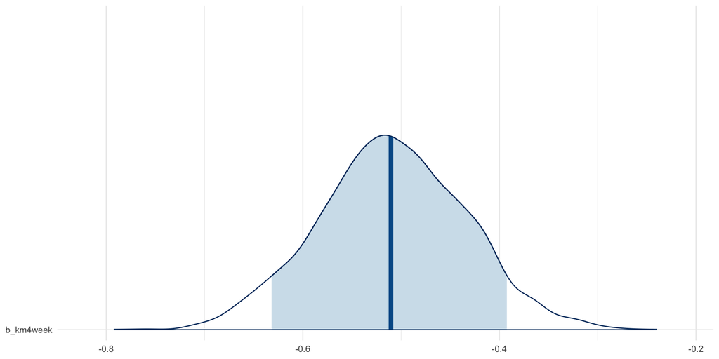

## Frequentist compared to Bayesian inference

You can explore a tutorial App of J. Krushke (2019)  
https://iupbsapps.shinyapps.io/KruschkeFreqAndBayesApp/

He has also written a nice tutorial, linked to this App:  
https://jkkweb.sitehost.iu.edu/KruschkeFreqAndBayesAppTutorial.html

## Advantages & Disadvantages of Bayesian analyses

Advantages:

- Natural approach to express uncertainty
- Ability to incorporate prior knowledge
- Increased model flexibility
- Full posterior distribution of the parameters
- Natural propagation of uncertainty

Disadvantage:

- Slow speed of model estimation
- Some reviewers don’t understand you (*“give me the p-value”*)

Slight adaptation of a slide from Paul Bürkner’s presentation available on YouTube: https://www.youtube.com/watch?v=FRs1iribZME

# Bayesian Inference

## Bayesian Theorem

[figure not shown]

$$P(\theta|data) = \frac{P(data|\theta)P(\theta)}{P(data)}$$
with

- $P(data|\theta)$ : the likelihood of the data given our model $\theta$
- $P(\theta)$ : our prior belief about values for the model parameters
- $P(\theta|data)$: the posterior probability for model parameter values

meme from https://twitter.com/ChelseaParlett/status/1421291716229746689?s=20

## Likelihood

$P(data|\theta)$ : the likelihood of the data given our model $\theta$

This part is about our MODEL and the parameters (aka the unknowns) in that model

> Example: a model on “time needed to run a marathon” could be a normal distribution: $y_i \backsim N(\mu, \sigma)$

So: for a certain average ($\mu$) and standard deviation ($\sigma$) we can calculate the probability of observing a marathon time of 240 minutes

## Prior

Expression of our prior knowledge (belief) on the parameter values

> Example: a model on “time needed to run a marathon” could be a normal distribution $y_i \backsim N(\mu, \sigma)$

e.g., How probable is an average marathon time of 120 minutes ($P(\mu=120)$) and how probable is a standard deviation of 40 minutes ($P(\sigma=40)$)?

## Prior as a distribution

How probable are different values as average marathon time in a population?

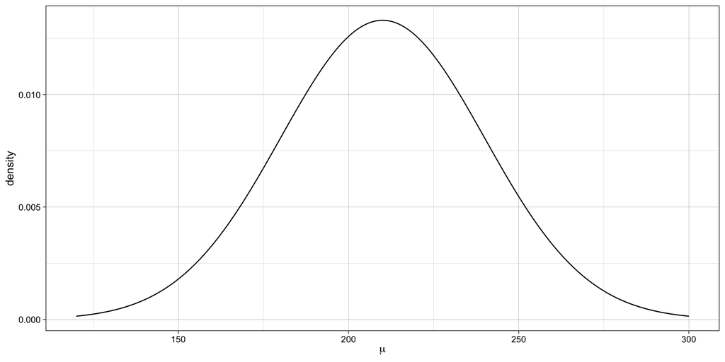

## Types of priors

Uninformative/Weakly informative

When objectivity is crucial and you want *let the data speak for itself…*

Informative

When including significant information is crucial

- previously collected data
- results from former research/analyses
- data of another source
- theoretical considerations
- elicitation

## Type of priors (visually)

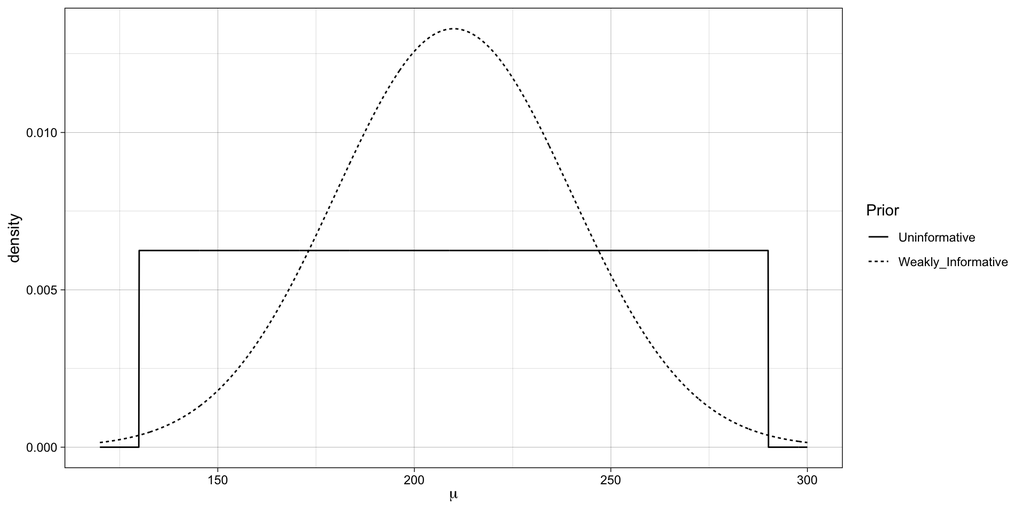

Two potential priors for the *mean marathon time* in the population

## Bayesian theorem in stats

*“For Bayesians, the data are treated as fixed and the parameters vary. […] Bayes’ rule tells us that to calculate the posterior probability distribution we must combine a likelihood with a prior probability distribution over parameter values.”*  
(Lambert, 2018, p.88)

## Let’s apply this idea

Our **Model** for marathon times

$y_i \backsim N(\mu, \sigma)$

## Let’s apply this idea

Our **Priors** related to mu and sigma:

```r
par(mfrow=c(2,2))
curve( dnorm( x , 210 , 30 ) , from=120 , to=300 ,xlab="mu", main="Prior for mu")
curve( dunif( x , 1 , 40 ) , from=-5 , to=50 ,xlab="sigma", main="Prior for sigma")
```

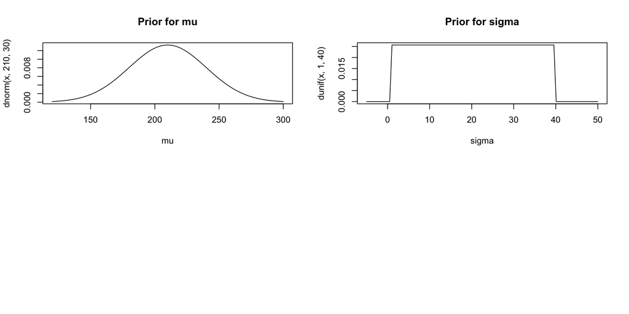

## Let’s apply this idea

Our **data**:

```
 [1] 185 193 240 245 155 234 189 196 206 263
```

## Let’s apply this idea

What is the **posterior probability** of mu = 180 combined with a sigma = 15?

```r
# Calculate the likelihood of the data
# given these parameter values of
# mu = 180 ; sigma = 15
# remember MT contains our data
Likelihood <-
  sum(
      dnorm(
        MT ,
        mean=180 ,
        sd=15)
      )
Likelihood
```

```
[1] 0.09330546
```

```r
# Calculate our Prior belief

Prior <- dnorm(180, 210 , 30 ) * dunif(15 , 1 , 40 )

Prior
```

```
[1] 0.0002068126
```

```r
# Calculate posterior as product
# of Likelihood and Prior

Product <- Likelihood * Prior

Product
```

```
[1] 0.00001929674
```

## Let’s apply this idea

What is the **posterior probability** of mu = 210 combined with a sigma = 30?

```r
# Calculate the likelihood of the data
# given these parameter values of
# mu = 210 ; sigma = 30
# remember MT contains our data
Likelihood <-
  sum(
      dnorm(
        MT ,
        mean=210 ,
        sd=30)
      )
Likelihood
```

```
[1] 0.08596287
```

```r
# Calculate our Prior belief

Prior <- dnorm(210, 210 , 30 ) * dunif(30 , 1 , 40 )

Prior
```

```
[1] 0.0003409763
```

```r
# Calculate posterior as product
# of Likelihood and Prior

Product <- Likelihood * Prior

Product
```

```
[1] 0.0000293113
```

## Grid approximation

We calculated the posterior probability of a combination of 2 parameters

We could repeat this systematically for following values:

```r
# sample some values for mu and sigma
mu.list <- seq(from = 135,
               to = 300,
               length.out=400)
sigma.list <- seq(from = 1,
                  to = 40,
                  length.out = 400)
```

aka: we create a grid of possible parameter value combinations and approx the distribution of posterior probabilities

## Grid approximation applied

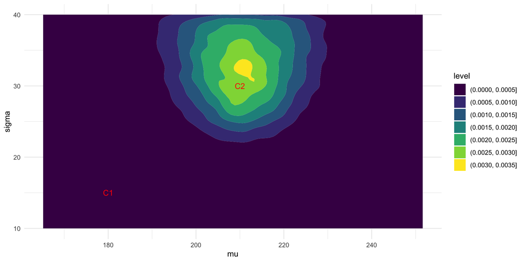

C1: first combo of mu and sigma

& C2: second combo of mu and sigma

## Sampling parameter values

- Instead of a fixed grid of combinations of parameter values,
- sample pairs/triplets/… of parameter values
- reconstruct the posterior probability distribution

# Why `brms`?

## Imagine

A ‘simple’ linear model

$$\begin{aligned}
& MT_{i} \sim N(\mu,\sigma_{e_{i}})\\
& \mu = \beta_0 + \beta_1*\text{sp4week}_{i} + \beta_2*\text{km4week}_{i} + \\
& \beta_3*\text{Age}_{i} + \beta_4*\text{Gender}_{i} + \beta_5*\text{CrossTraining}_{i} \\
\end{aligned}$$

So you can get a REALLY LARGE number of parameters!

## Markov Chain Monte Carlo - Why?

Complex models $\rightarrow$ Large number of parameters $\rightarrow$ exponentionally large number of combinations!

Posterior gets unsolvable by grid approximation

We will approximate the ‘joint posterior’ by ‘smart’ sampling

Samples of combinations of parameter values are drawn

BUT: samples will not be random!

## MCMC - demonstrated

Following link brings you to an interactive tool that let’s you get the basic idea behind MCMC sampling:

https://chi-feng.github.io/mcmc-demo/app.html#HamiltonianMC,standard

## Software

- different dedicated software/packages are available: JAGS / BUGS / Stan
- most powerful is Stan! Specifically the *Hamiltonian Monte Carlo* algorithm makes it the best choice at the moment
- Stan is a probabilistic programming language that uses C++

## Example of Stan code

```
// generated with brms 2.14.4
functions {
}
data {
  int<lower=1> N;  // total number of observations
  vector[N] Y;  // response variable
  int prior_only;  // should the likelihood be ignored?
}
transformed data {
}
parameters {
  real Intercept;  // temporary intercept for centered predictors
  real<lower=0> sigma;  // residual SD
}
transformed parameters {
}
model {
  // likelihood including all constants
  if (!prior_only) {
    // initialize linear predictor term
    vector[N] mu = Intercept + rep_vector(0.0, N);
    target += normal_lpdf(Y | mu, sigma);
  }
  // priors including all constants
  target += normal_lpdf(Intercept | 500,50);
  target += student_t_lpdf(sigma | 3, 0, 68.8)
    - 1 * student_t_lccdf(0 | 3, 0, 68.8);
}
generated quantities {
  // actual population-level intercept
  real b_Intercept = Intercept;
}
```

## How `brms` works

[figure not shown]

# The basics of `brms`

## `brms` syntax

Very very similar to `lm` or `lme4` and in line with typical R-style writing up of a model …

`lme4`

```r
Model <- lmer(
  y ~ x1 + x2 + (1|Group),
  data = Data,

  ...
)
```

`brms`

```r
Model <- brm(
  y ~ x1 + x2 + (1|Group),
  data = Data,
  family = "gaussian",
  backend = "cmdstanr",

  ...
)
```

Notice:

- `backend = "cmdstanr"` indicates the way we want to interact with Stan and C++

## Let’s retake the example on running

The simplest model looked like:

$$MT_i \sim N(\mu,\sigma_e)$$

In `brms` this model is:

```r
MT <- c(185, 193, 240, 245, 155, 234, 189, 196, 206, 263)

# First make a dataset from our MT vector
DataMT <- data_frame(MT)

Mod_MT1 <- brm(
  MT ~ 1, # We only model an intercept
  data = DataMT,
  backend = "cmdstanr",
  seed = 1975
)
```

**1**

create a dataset with potential marathon times

**2**

change it to a data frame

**3**

the brm() commando runs the model

**4**

define the model

**5**

define the dataset to us

**6**

how brms and stan communicate

**7**

make the estimation reproducible

**🏃 Try it yourself and run the model … (don’t forget to load the necessary packages: `brms` & `tidyverse`)**

## Basic output `brms`

```r
summary(Mod_MT1)
```

## Basic output `brms`

```
 Family: gaussian
  Links: mu = identity; sigma = identity
Formula: MT ~ 1
   Data: DataMT (Number of observations: 10)
  Draws: 4 chains, each with iter = 2000; warmup = 1000; thin = 1;
         total post-warmup draws = 4000

Regression Coefficients:
          Estimate Est.Error l-95% CI u-95% CI Rhat Bulk_ESS Tail_ESS
Intercept   209.58     11.18   187.37   231.78 1.00     2386     1935

Further Distributional Parameters:
      Estimate Est.Error l-95% CI u-95% CI Rhat Bulk_ESS Tail_ESS
sigma    36.21      9.51    23.26    58.13 1.00     2487     2329

Draws were sampled using sample(hmc). For each parameter, Bulk_ESS
and Tail_ESS are effective sample size measures, and Rhat is the potential
scale reduction factor on split chains (at convergence, Rhat = 1).
```

## About chains and iterations

Markov Chain Monte Carlo

- A chain of samples of parameter values
- It is advised to run multiple chains
- Each sample of parameter values is called an iteration
- First X iterations are used to tune the sampler but not used to interpret the results: X burn-in iterations

`brms` defaults with **4 chains** each of **2000 iterations** of which **1000 iterations** are used as burn-in

## Changing `brms` defaults

```r
Mod_MT1 <- brm(
  MT ~ 1,
  data = DataMT,
  backend = "cmdstanr",
  chains = 5,
  iter = 6000,
  warmup = 1500,
  cores = 4,
  seed = 1975
)
```

## Good old `plot()` function

```r
plot(Mod_MT1)
```

## Good old `plot()` function

[figure not shown]

## Results Exercise

*Model1: only an intercept (brms defaults)*

```r
load(file = here(
    "Presentations",
    "MarathonData.RData")
    )

Mod_MT1 <- brm(
  MarathonTimeM ~ 1,
  data = MarathonData,
  backend = "cmdstanr",
  seed = 1975
)
```

[output not shown]

[output cut: 43 more lines]

[output not shown]

## Results Exercise

*Model1: only an intercept (brms defaults)*

```r
summary(Mod_MT1)
```

```
 Family: gaussian
  Links: mu = identity; sigma = identity
Formula: MarathonTimeM ~ 1
   Data: MarathonData (Number of observations: 87)
  Draws: 4 chains, each with iter = 2000; warmup = 1000; thin = 1;
         total post-warmup draws = 4000

Regression Coefficients:
          Estimate Est.Error l-95% CI u-95% CI Rhat Bulk_ESS Tail_ESS
Intercept   199.12      2.42   194.38   203.76 1.00     2903     2125

Further Distributional Parameters:
      Estimate Est.Error l-95% CI u-95% CI Rhat Bulk_ESS Tail_ESS
sigma    22.84      1.73    19.72    26.39 1.00     3314     2946

Draws were sampled using sample(hmc). For each parameter, Bulk_ESS
and Tail_ESS are effective sample size measures, and Rhat is the potential
scale reduction factor on split chains (at convergence, Rhat = 1).
```

## Results Exercise

*Model1: only an intercept (brms defaults)*

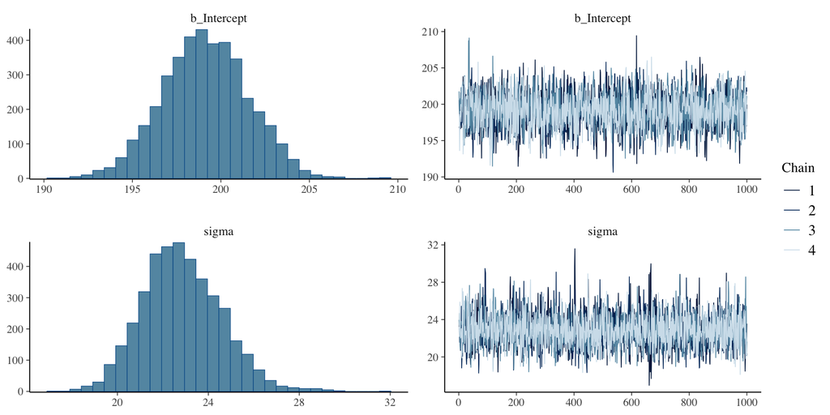

```r
plot(Mod_MT1)
```

## Results Exercise

*Model2: add the effect of* `km4week` *and* `sp4week`

```r
Mod_MT2 <- brm(
  MarathonTimeM ~ 1 + km4week + sp4week,
  data = MarathonData,
  backend = "cmdstanr",
  seed = 1975
)
```

[output not shown]

[output cut: 43 more lines]

[output not shown]

## Results Exercise

*Model2: add the effect of* `km4week` *and* `sp4week`

```r
summary(Mod_MT2)
```

```
 Family: gaussian
  Links: mu = identity; sigma = identity
Formula: MarathonTimeM ~ 1 + km4week + sp4week
   Data: MarathonData (Number of observations: 87)
  Draws: 4 chains, each with iter = 2000; warmup = 1000; thin = 1;
         total post-warmup draws = 4000

Regression Coefficients:
          Estimate Est.Error l-95% CI u-95% CI Rhat Bulk_ESS Tail_ESS
Intercept   199.20      1.50   196.28   202.15 1.00     3852     2838
km4week      -0.42      0.06    -0.53    -0.31 1.00     4189     3157
sp4week      -9.98      1.30   -12.46    -7.50 1.00     4402     3263

Further Distributional Parameters:
      Estimate Est.Error l-95% CI u-95% CI Rhat Bulk_ESS Tail_ESS
sigma    13.94      1.09    11.96    16.29 1.00     3991     3236

Draws were sampled using sample(hmc). For each parameter, Bulk_ESS
and Tail_ESS are effective sample size measures, and Rhat is the potential
scale reduction factor on split chains (at convergence, Rhat = 1).
```

## Results Exercise

*Model2: add the effect of* `km4week` *and* `sp4week`

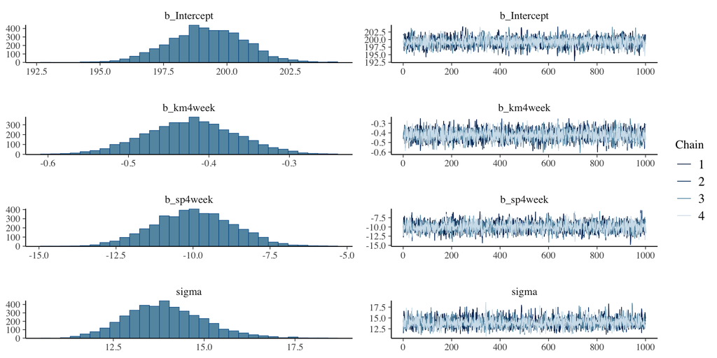

```r
plot(Mod_MT2)
```

## Results Exercise

*Model3: change the brms defaults*

```r
Mod_MT3 <- brm(
  MarathonTimeM ~ 1 + km4week + sp4week,
  data = MarathonData,
  chains = 4,
  iter = 4000,
  cores = 4,
  backend = "cmdstanr",
  seed = 1975
)
```

[output not shown]

[output cut: 123 more lines]

[output not shown]

## Results Exercise

*Model3: change the brms defaults*

```r
summary(Mod_MT3)
```

```
 Family: gaussian
  Links: mu = identity; sigma = identity
Formula: MarathonTimeM ~ 1 + km4week + sp4week
   Data: MarathonData (Number of observations: 87)
  Draws: 4 chains, each with iter = 4000; warmup = 2000; thin = 1;
         total post-warmup draws = 8000

Regression Coefficients:
          Estimate Est.Error l-95% CI u-95% CI Rhat Bulk_ESS Tail_ESS
Intercept   199.15      1.51   196.21   202.14 1.00     8054     5568
km4week      -0.42      0.06    -0.53    -0.31 1.00     8127     5617
sp4week      -9.98      1.29   -12.50    -7.48 1.00     8080     6304

Further Distributional Parameters:
      Estimate Est.Error l-95% CI u-95% CI Rhat Bulk_ESS Tail_ESS
sigma    13.92      1.07    12.02    16.22 1.00     7672     5845

Draws were sampled using sample(hmc). For each parameter, Bulk_ESS
and Tail_ESS are effective sample size measures, and Rhat is the potential
scale reduction factor on split chains (at convergence, Rhat = 1).
```

## Results Exercise

*Model3: change the brms defaults*

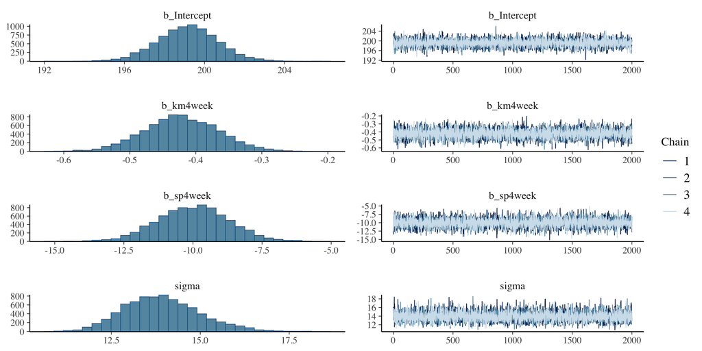

```r
plot(Mod_MT3)
```

## About convergence

[figure not shown]

## But is it a good model?

Two complementary procedures:

- posterior-predictive check
- compare models with *leave one out cross-validation*

## Posterior-predictive check

A visual check that can be performed with `pp_check()` from `brms`

```r
MarathonTimes_Mod2 <-
  readRDS(file =
            here("Presentations",
              "Output",
              "MarathonTimes_Mod2.RDS")
          )

pp_check(MarathonTimes_Mod2) + theme_minimal()
```

## Posterior-predictive check

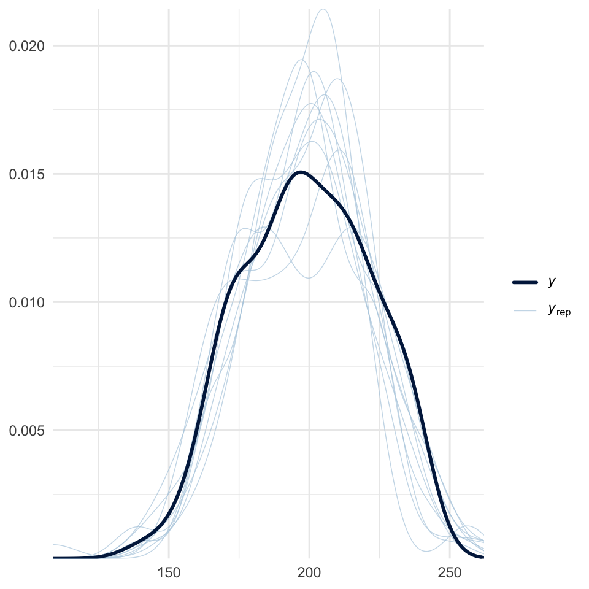

## Model comparison with loo cross-validation

$\sim$ AIC or BIC in Frequentist statistics

$\widehat{elpd}$: “expected log predictive density” (higher $\widehat{elpd}$ implies better model fit without being sensitive for overfitting!)

```r
loo_Mod1 <- loo(MarathonTimes_Mod1)
loo_Mod2 <- loo(MarathonTimes_Mod2)

Comparison<-
  loo_compare(
    loo_Mod1,
    loo_Mod2
    )

print(Comparison, simplify = F)
```

## Model comparison with loo cross-validation

```
                   elpd_diff se_diff elpd_loo se_elpd_loo p_loo  se_p_loo
MarathonTimes_Mod2    0.0       0.0  -356.3     12.0         7.2    4.4
MarathonTimes_Mod1  -39.9      12.6  -396.2      5.3         1.7    0.3
                   looic  se_looic
MarathonTimes_Mod2  712.6   24.0
MarathonTimes_Mod1  792.3   10.6
```

## Your Turn

- Time to switch to `your dataset`
- Think of `two alternative models` for a certain variable
- Be naive! Let’s `assume normality` and
- `Keep it simple`
- Estimate the two models
- Compare the models
- Interpret the best fitting model
- Check the fit with `pp_check()`

## Family time

`brms` defaults to `family = gaussian(link = "identity")`

```r
Mod_MT1 <- brm(
  MT ~ 1,
  family = gaussian(link = "identity"),
  data = DataMT,
  backend = "cmdstanr",
  chains = 5,
  iter = 6000,
  warmup = 1500,
  cores = 4,
  seed = 1975
)
```

## Family time

But many alternatives are available!

The default `family` types known in `R` (e.g, `binomial(link = "logit")`, `Gamma(link = "inverse")`, `poisson(link = "log")`, …)

see `help(family)`

```r
ModX <- brm(
  Y ~ 1,
  family = binomial(link = "logit"),
  ...
)
```

## Family time

And even more!

`brmsfamily(...)` has a lot of possible models

see `help(brmsfamily)`

```r
ModX <- brm(
  Y ~ 1,
  family = brmsfamily(skew_normal,
                      link = "identity",
                      link_sigma = "log",
                      link_alpha = "identity"),
  ...
)
```

## Mixed effects models

`brms` can estimate models for more complex designs like `multilevel models` or more generally `mixed effects models`

Random intercepts…

```r
ModX <- brm(
  Y ~ 1 + x +
    (1 | Groupvariable),
  ...
)
```

Random intercepts and slopes…

```r
ModX <- brm(
  Y ~ 1 + x +
    (1 + x | Groupvariable),
  ...
)
```

# Homework

Time to think about `your data` and research question

- Define a simple model?
- What are the parameters in that model?
- What are your `prior beliefs` about each of the parameters?
- Minimum and maximum values assumed for each parameter?
- Do all potential parameter values have a similar probability?
- Bring along your notes to the next session!